# ValidationSchemesTest

### Goals

- Develop validation methods for training, validation and test phases.
- Use building permits for testing of setup to ensure as close as possible to real ase.

# I. Retrieve data

Load the data.

```r
path <- "/home/jovyan/forecasting_data_ingestion/notebooks/"
source_python(paste(path, "load_es_data.py", sep=""))
creds = fromJSON(file=paste(path, "cred.json", sep=""))
indexname = "buildingpermits"
permits <- load_from_es(creds, indexname)
```

[output not shown]

[output cut: 96 more lines]

[output not shown]

```
trying to connect to ES...
connection successfull
Number of documents loaded successfully:  47072
Number of documents failed to load:  0
Execution time:  0:00:15.633172
```

```r
dim(permits)
```

```
[1] 47072    11
```

```r
head(permits)
```

|  | type_of_structure | type_of_work | variables | seasonal_adjustment | geo | ref_date | value | uom | creation_date | es_id | es_index |
| --- | --- | --- | --- | --- | --- | --- | --- | --- | --- | --- | --- |
| 1 | Multiple dwelling building total | Types of work, total | Value of permits | Unadjusted | Ontario | 2018-10-01T00:00:00.000001 | 1394702 | Dollars | 2020-10-29T17:39:47.902011 | Lh5xdXUBrYYIKter7cKa | buildingpermits |
| 2 | Multiple dwelling building total | Types of work, total | Value of permits | Seasonally adjusted | Ontario | 2018-10-01T00:00:00.000001 | 1231601 | Dollars | 2020-10-29T17:39:47.902011 | Lx5xdXUBrYYIKter7cKa | buildingpermits |
| 3 | Multiple dwelling building total | Types of work, total | Number of permits | Unadjusted | Ontario | 2018-10-01T00:00:00.000001 | 1843 | Number | 2020-10-29T17:39:47.902011 | MB5xdXUBrYYIKter7cKa | buildingpermits |
| 4 | Multiple dwelling building total | New construction | Value of permits | Unadjusted | Ontario | 2018-10-01T00:00:00.000001 | 1244058 | Dollars | 2020-10-29T17:39:47.902011 | MR5xdXUBrYYIKter7cKa | buildingpermits |
| 5 | Multiple dwelling building total | New construction | Number of permits | Unadjusted | Ontario | 2018-10-01T00:00:00.000001 | 842 | Number | 2020-10-29T17:39:47.902011 | Mh5xdXUBrYYIKter7cKa | buildingpermits |
| 6 | Multiple dwelling building total | Conversions total | Value of permits | Unadjusted | Ontario | 2018-10-01T00:00:00.000001 | 44560 | Dollars | 2020-10-29T17:39:47.902011 | Mx5xdXUBrYYIKter7cKa | buildingpermits |

```r
permits$ref_date <- as.Date(permits$ref_date)
```

## II. Data Exploration

Building permits start at 2011?

```r
summary(permits)
```

```
 type_of_structure  type_of_work        variables         seasonal_adjustment     geo               ref_date              value
 Length:47072       Length:47072       Length:47072       Length:47072        Length:47072       Min.   :2011-01-01   Min.   :       0
 Class :character   Class :character   Class :character   Class :character    Class :character   1st Qu.:2015-05-01   1st Qu.:      21
 Mode  :character   Mode  :character   Mode  :character   Mode  :character    Mode  :character   Median :2018-06-01   Median :    3981
                                                                                                 Mean   :2017-05-09   Mean   :  241516
                                                                                                 3rd Qu.:2019-07-01   3rd Qu.:   81997
                                                                                                 Max.   :2020-08-01   Max.   :10672320
     uom            creation_date         es_id             es_index
 Length:47072       Length:47072       Length:47072       Length:47072
 Class :character   Class :character   Class :character   Class :character
 Mode  :character   Mode  :character   Mode  :character   Mode  :character
```

```r
min(as.Date(permits$ref_date))
```

```
[1] "2011-01-01"
```

## Filter out one series for testing

Pick value of permits, choose `Value of permits`. Which one to forecast?

```r
table(permits$variables)
```

```
Number of permits  Value of permits
            12380             34692
```

Choose `Total residential and non-residential` for now.

```r
table(permits$type_of_structure)
```

```
     Multiple dwelling building total        Single dwelling building total                      Total commercial
                                 6330                                  6337                                  5440
                     Total industrial  Total institutional and governmental                 Total non-residential
                                 5429                                  5441                                  5439
                    Total residential Total residential and non-residential
                                 6326                                  6330
```

Choose `Types of work, total` for now:

```r
table(permits$type_of_work)
```

```
   Conversions total   Deconversion total     New construction Types of work, total
                3538                 7114                 7056                29364
```

Choose Canada

```r
table(permits$geo)
```

```
                  Alberta          British Columbia                    Canada                  Manitoba             New Brunswick
                     3392                      3388                      3392                      3392                      3390
Newfoundland and Labrador     Northwest Territories               Nova Scotia                   Nunavut                   Ontario
                     3387                      3332                      3392                      3048                      3392
     Prince Edward Island                    Quebec              Saskatchewan                     Yukon
                     3392                      3391                      3392                      3392
```

```r
table(permits$seasonal_adjustment)
```

```
Seasonally adjusted          Unadjusted
              12933               34139
```

```r
permits_series <- permits %>%
  filter(variables=="Value of permits",
         type_of_structure=="Total residential and non-residential",
         type_of_work=="Types of work, total",
         geo=="Canada",
         seasonal_adjustment=="Seasonally adjusted")
head(permits_series)
```

|  | type_of_structure | type_of_work | variables | seasonal_adjustment | geo | ref_date | value | uom | creation_date | es_id | es_index |
| --- | --- | --- | --- | --- | --- | --- | --- | --- | --- | --- | --- |
| 1 | Total residential and non-residential | Types of work, total | Value of permits | Seasonally adjusted | Canada | 2018-11-01 | 8534467 | Dollars | 2020-10-29T17:39:47.902011 | bN5xdXUB_W5yC9KJ7ksH | buildingpermits |
| 2 | Total residential and non-residential | Types of work, total | Value of permits | Seasonally adjusted | Canada | 2018-12-01 | 8868054 | Dollars | 2020-10-29T17:39:47.902011 | 6t5xdXUB_W5yC9KJ7ky1 | buildingpermits |
| 3 | Total residential and non-residential | Types of work, total | Value of permits | Seasonally adjusted | Canada | 2019-01-01 | 8345559 | Dollars | 2020-10-29T17:39:47.902011 | _h5xdXUBrYYIKter78YK | buildingpermits |
| 4 | Total residential and non-residential | Types of work, total | Value of permits | Seasonally adjusted | Canada | 2019-02-01 | 8018253 | Dollars | 2020-10-29T17:39:47.902011 | ih5xdXUBrYYIKter78i2 | buildingpermits |
| 5 | Total residential and non-residential | Types of work, total | Value of permits | Seasonally adjusted | Canada | 2019-03-01 | 8354097 | Dollars | 2020-10-29T17:39:47.902011 | Fh5xdXUBrYYIKter8Mpj | buildingpermits |
| 6 | Total residential and non-residential | Types of work, total | Value of permits | Seasonally adjusted | Canada | 2019-04-01 | 9595965 | Dollars | 2020-10-29T17:39:47.902011 | oh5xdXUBrYYIKter8csN | buildingpermits |

Ensure unique series after filtering.

```r
sapply(permits_series, function (x) length(unique(x)))
```

```
  type_of_structure        type_of_work           variables seasonal_adjustment                 geo            ref_date
                  1                   1                   1                   1                   1                 116
              value                 uom       creation_date               es_id            es_index
                116                   1                   1                 116                   1
```

```r
dim(permits_series)
```

```
[1] 116  11
```

## Visualization of test series

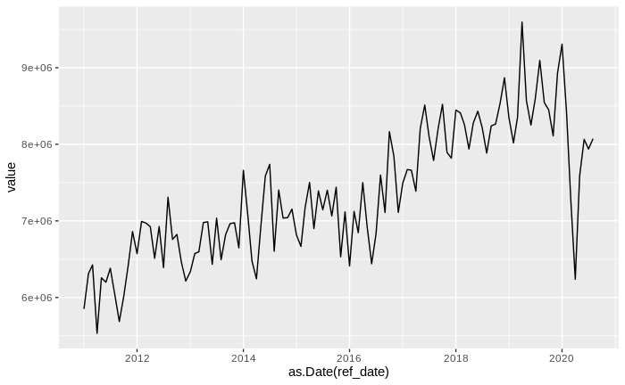

```r
ggplot(permits_series) + geom_line(aes(x=as.Date(ref_date), y=value))
```

```r
permits_series[, c("ref_date", "value")]
```

| ref_date | value |
| --- | --- |
| 2018-11-01 | 8534467 |
| 2018-12-01 | 8868054 |
| 2019-01-01 | 8345559 |
| 2019-02-01 | 8018253 |
| 2019-03-01 | 8354097 |
| 2019-04-01 | 9595965 |
| 2019-05-01 | 8570804 |
| 2018-05-01 | 8279684 |
| 2018-06-01 | 8431857 |
| 2018-07-01 | 8218103 |

[output cut: 106 more lines]